# Practical_ML_Course_Project – Wearable Computing

Alari Varmann

28 June 2016

## Introduction

*Using devices such as Jawbone Up, Nike FuelBand, and Fitbit it is now possible to collect a large amount of data about personal activity relatively inexpensively. These type of devices are part of the quantified self movement — a group of enthusiasts who take measurements about themselves regularly to improve their health, to find patterns in their behavior, or because they are tech geeks. One thing that people regularly do is quantify how much of a particular activity they do, but they rarely quantify how well they do it. In this project, your goal will be to use data from accelerometers on the belt, forearm, arm, and dumbell of 6 participants. They were asked to perform barbell lifts correctly and incorrectly in 5 different ways. More information is available from the website here*: http://groupware.les.inf.puc-rio.br/har

## The Datasets

The training data for this project are available here:

https://d396qusza40orc.cloudfront.net/predmachlearn/pml-training.csv

The test data are available here:

https://d396qusza40orc.cloudfront.net/predmachlearn/pml-testing.csv

The original article is located at [Wearable Computing: Accelerometers’ Data Classification of Body Postures and Movements](http://groupware.les.inf.puc-rio.br/public/papers/2012.Ugulino.WearableComputing.HAR.Classifier.RIBBON.pdf)

## Task Description

*You should create a report describing how you built your model, how you used cross validation, what you think the expected out of sample error is, and why you made the choices you did. You will also use your prediction model to predict 20 different test cases.*

## Getting and Cleaning Data, Exploratory Analysis

```r
# remove dplyr if loaded detach_package(dplyr)
# first load plyr
RequireOrInstall("plyr")
# then load dplyr
RequireOrInstall("dplyr")

# NAVIGATE TO DATASETS DIRECTORY USING setwd() command
training <- read.csv("pml-training.csv")
testing <- read.csv("pml-testing.csv")
dim(training) # 19622 rows, 160 cols
```

```
## [1] 19622   160
```

```r
dim(testing) # 20 rows, 160 cols
```

```
## [1]  20 160
```

```r
fulldata <- bind_rows(training,testing)

check_for_NAs <- function(x,useceil=F){
  if(useceil==T){
  apply(as.data.frame(x),2,FUN=function(x){ceiling(sum(is.na(x))/length(x))})
  } else {
    apply(as.data.frame(x),2,FUN=function(x){sum(is.na(x))/length(x)})
  }
}

NAs <- check_for_NAs(fulldata,useceil = T)
NAs_w <- check_for_NAs(fulldata,useceil = F)
NAs_n <- as.numeric(NAs) # 67 NA variables -- so we have 160 - 67 = 93 that are mostly free of NA's

featuredata <- fulldata%>%select(which(NAs_n==0))
dim(featuredata)
```

```
## [1] 19642    59
```

```r
# these variables have less than 50% NA variables also subsetted out
features <- names(fulldata[,colSums(is.na(fulldata)) == 0])
features
```

```
##  [1] "X"                    "user_name"            "raw_timestamp_part_1"
##  [4] "raw_timestamp_part_2" "cvtd_timestamp"       "new_window"
##  [7] "num_window"           "roll_belt"            "pitch_belt"
## [10] "yaw_belt"             "total_accel_belt"     "gyros_belt_x"
## [13] "gyros_belt_y"         "gyros_belt_z"         "accel_belt_x"
## [16] "accel_belt_y"         "accel_belt_z"         "magnet_belt_x"
## [19] "magnet_belt_y"        "magnet_belt_z"        "roll_arm"
## [22] "pitch_arm"            "yaw_arm"              "total_accel_arm"
## [25] "gyros_arm_x"          "gyros_arm_y"          "gyros_arm_z"
## [28] "accel_arm_x"          "accel_arm_y"          "accel_arm_z"
## [31] "magnet_arm_x"         "magnet_arm_y"         "magnet_arm_z"
## [34] "roll_dumbbell"        "pitch_dumbbell"       "yaw_dumbbell"
## [37] "total_accel_dumbbell" "gyros_dumbbell_x"     "gyros_dumbbell_y"
## [40] "gyros_dumbbell_z"     "accel_dumbbell_x"     "accel_dumbbell_y"
## [43] "accel_dumbbell_z"     "magnet_dumbbell_x"    "magnet_dumbbell_y"
## [46] "magnet_dumbbell_z"    "roll_forearm"         "pitch_forearm"
## [49] "yaw_forearm"          "total_accel_forearm"  "gyros_forearm_x"
## [52] "gyros_forearm_y"      "gyros_forearm_z"      "accel_forearm_x"
## [55] "accel_forearm_y"      "accel_forearm_z"      "magnet_forearm_x"
## [58] "magnet_forearm_y"     "magnet_forearm_z"
```

```r
length(features) # so only 59 of 93 variables contain no NA's
```

```
## [1] 59
```

```r
featuredata<- subset(featuredata, select = features)
featuredata
```

```
## Source: local data frame [19,642 x 59]
##
##        X user_name raw_timestamp_part_1 raw_timestamp_part_2
##    (int)    (fctr)                (int)                (int)
## 1      1  carlitos           1323084231               788290
## 2      2  carlitos           1323084231               808298
## 3      3  carlitos           1323084231               820366
## 4      4  carlitos           1323084232               120339
## 5      5  carlitos           1323084232               196328
## 6      6  carlitos           1323084232               304277
## 7      7  carlitos           1323084232               368296
## 8      8  carlitos           1323084232               440390
## 9      9  carlitos           1323084232               484323
## 10    10  carlitos           1323084232               484434
## ..   ...       ...                  ...                  ...
## Variables not shown: cvtd_timestamp (chr), new_window (chr), num_window
##   (int), roll_belt (dbl), pitch_belt (dbl), yaw_belt (dbl),
##   total_accel_belt (int), gyros_belt_x (dbl), gyros_belt_y (dbl),
##   gyros_belt_z (dbl), accel_belt_x (int), accel_belt_y (int), accel_belt_z
##   (int), magnet_belt_x (int), magnet_belt_y (int), magnet_belt_z (int),
##   roll_arm (dbl), pitch_arm (dbl), yaw_arm (dbl), total_accel_arm (int),
##   gyros_arm_x (dbl), gyros_arm_y (dbl), gyros_arm_z (dbl), accel_arm_x
##   (int), accel_arm_y (int), accel_arm_z (int), magnet_arm_x (int),
##   magnet_arm_y (int), magnet_arm_z (int), roll_dumbbell (dbl),
##   pitch_dumbbell (dbl), yaw_dumbbell (dbl), total_accel_dumbbell (int),
##   gyros_dumbbell_x (dbl), gyros_dumbbell_y (dbl), gyros_dumbbell_z (dbl),
##   accel_dumbbell_x (int), accel_dumbbell_y (int), accel_dumbbell_z (int),
##   magnet_dumbbell_x (int), magnet_dumbbell_y (int), magnet_dumbbell_z
##   (dbl), roll_forearm (dbl), pitch_forearm (dbl), yaw_forearm (dbl),
##   total_accel_forearm (int), gyros_forearm_x (dbl), gyros_forearm_y (dbl),
##   gyros_forearm_z (dbl), accel_forearm_x (int), accel_forearm_y (int),
##   accel_forearm_z (int), magnet_forearm_x (int), magnet_forearm_y (dbl),
##   magnet_forearm_z (dbl)
```

```r
#dropping the features related to timeseries
train <- as.data.frame(mutate(featuredata[1:19622,],classe=training$classe)[,c(2,8:60)])
test <- as.data.frame(featuredata[19623:19642,c(2,8:60)])
```

### Data Preprocessing – Removing Redundant Multi-Collinearities from Data

I have not opted for to use the famous `Principal Component Analysis` preprocessing technique here since rotating the feature space will possibly result in a loss of descriptive power that I have not planned here. Thus, instead, I have chosen to remove the unnecessary collinearities in the data in the following way:

```r
set.seed(123)
RequireOrInstall("caret")
numericset_names <- names(train[,sapply(train,is.numeric)|sapply(train,is.integer)])

numericset <- train[,sapply(train,is.numeric)|sapply(train,is.integer)]

#findCorrelation  searches through a correlation matrix and returns a vector of integers corresponding to columns to remove to reduce pair-wise correlations.

highCor_feat <- names(numericset[,findCorrelation(abs(cor(numericset)),0.88)])
lowcor_features <- setdiff(setdiff(names(train),"classe"),highCor_feat)

train_lowcor <- train[,c(lowcor_features,"classe")]
dim(train_lowcor)
```

```
## [1] 19622    46
```

```r
#### ----------- 19623:19642 TESTING, the rest TRAINING ---------- ########

inTrain <- createDataPartition(train_lowcor$classe, p = 0.6, list = F)
train_ = train_lowcor[inTrain,]
validate_ = train_lowcor[-inTrain,]
classe_idx = which(names(train_) == "classe")
classe_idx #index corresponds to classe
```

```
## [1] 46
```

```r
str(train_)
```

```
## 'data.frame':    11776 obs. of  46 variables:
##  $ user_name           : Factor w/ 6 levels "adelmo","carlitos",..: 2 2 2 2 2 2 2 2 2 2 ...
##  $ yaw_belt            : num  -94.4 -94.4 -94.4 -94.4 -94.4 -94.4 -94.4 -94.4 -94.4 -94.4 ...
##  $ total_accel_belt    : int  3 3 3 3 3 3 3 3 3 3 ...
##  $ gyros_belt_x        : num  0 0.02 0.02 0.03 0.03 0.02 0.02 0 0 0 ...
##  $ gyros_belt_y        : num  0 0 0 0 0 0 0 0 0.02 0 ...
##  $ gyros_belt_z        : num  -0.02 -0.03 -0.02 0 -0.02 -0.02 0 -0.02 0 -0.02 ...
##  $ magnet_belt_x       : int  -2 -6 0 -3 -5 -2 -3 -6 1 -3 ...
##  $ magnet_belt_y       : int  600 604 603 609 596 602 606 598 600 603 ...
##  $ magnet_belt_z       : int  -305 -310 -312 -308 -317 -319 -309 -317 -316 -313 ...
##  $ roll_arm            : num  -128 -128 -128 -128 -128 -128 -128 -129 -129 -129 ...
##  $ pitch_arm           : num  22.5 22.1 22 21.6 21.5 21.5 21.4 21.3 21.2 21.2 ...
##  $ yaw_arm             : num  -161 -161 -161 -161 -161 -161 -161 -161 -161 -161 ...
##  $ total_accel_arm     : int  34 34 34 34 34 34 34 34 34 34 ...
##  $ gyros_arm_y         : num  -0.02 -0.03 -0.03 -0.03 -0.03 -0.03 -0.02 0 -0.02 -0.02 ...
```

[output cut: 32 more lines]

```r
dim(validate_)
```

```
## [1] 7846   46
```

## Machine Learning Modeling

I used the default `randomForest` settings to build a classification algorithm – since it is a very powerful nonlinear model with potentially low bias, and the variance of which can be easily reduced using the cross-validation technique. I did not use a special cross validation set in parallel mode as I had split the training data into training and validation sets (60% and 40% of the initial training data size respectively), but I also performed cross validation for the random forest in serial mode.

I experimented with RandomForest and Support Vector Machine (SVM) classifiers.

I tried out a few runs of SVM, the first one with a sigmoidal and linear kernels (interestingly, `parallelSVM` doesn’t have a generic Gaussian kernel?), but I couldn’t figure it out fast how to make the 1-hot encoding for the parallel SVM to recognize multiple class response variable – that’s probably why it only made a binary classification (like it should by default) and that’s why the accuracy was only around 20% instead of near 100 %.

What I really opted for was the `Random Forest` classifier. I had some bug that I wasn’t able to fix – for some reason, cross validation did not work for my parallel impementation of `Random Forest` – I got some sort of confusing a runtime termination error. But the cross validation worked nicely with the Caret package, so I used cross-validation with the `train` function of `Caret`.

```r
printconfusion <- function(ml_model,validate_){
confusionMatrix(predict(ml_model,validate_),validate_$classe)
}
RequireOrInstall <- function(package) {
  suppressWarnings({
    if (!require(package,character.only=TRUE)) {
      install.packages(package, dep=TRUE)
      require(package,character.only=TRUE)
    }})
}
RequireOrInstall("randomForest")
RequireOrInstall("caret")
set.seed(123)
dim(train_)
```

```
## [1] 11776    46
```

```r
dim(validate_)
```

```
## [1] 7846   46
```

```r
classe_idx
```

```
## [1] 46
```

```r
samsung.randomforest2 <-train(train_[,-classe_idx],train_[,classe_idx],method="rf",trControl=trainControl(method="cv",number=5))

samsung.randomforest <- randomForest(train_[,-classe_idx], train_[,classe_idx], importance = T, ntree = 700 )
print(samsung.randomforest, digits=3)
```

```
##
## Call:
##  randomForest(x = train_[, -classe_idx], y = train_[, classe_idx],      ntree = 700, importance = T)
##                Type of random forest: classification
##                      Number of trees: 700
## No. of variables tried at each split: 6
##
##         OOB estimate of  error rate: 0.89%
## Confusion matrix:
##      A    B    C    D    E class.error
## A 3344    1    1    0    2 0.001194743
## B   17 2255    7    0    0 0.010530935
## C    0   27 2024    3    0 0.014605648
## D    2    0   34 1892    2 0.019689119
## E    0    0    2    7 2156 0.004157044
```

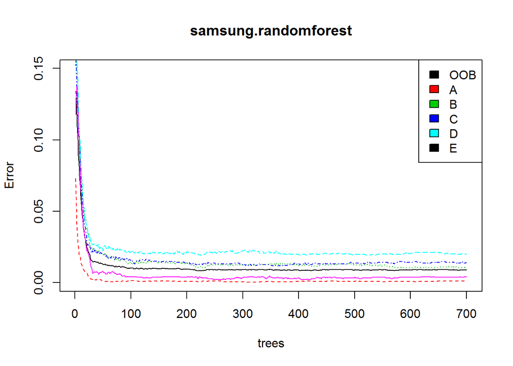

```r
# PLOT TRAINING ERROR
plot(samsung.randomforest, ylim=c(0,0.15))
legend('topright', colnames(samsung.randomforest$err.rate), col=1:5, fill=1:5)
```

```r
printconfusion(samsung.randomforest,validate_)
```

```
## Confusion Matrix and Statistics
##
##           Reference
## Prediction    A    B    C    D    E
##          A 2232    7    0    4    0
##          B    0 1508   17    1    0
##          C    0    3 1351   23    2
##          D    0    0    0 1256    3
##          E    0    0    0    2 1437
##
## Overall Statistics
##
##                Accuracy : 0.9921
##                  95% CI : (0.9899, 0.9939)
##     No Information Rate : 0.2845
##     P-Value [Acc > NIR] : < 2.2e-16
##
##                   Kappa : 0.99
##  Mcnemar's Test P-Value : NA
##
## Statistics by Class:
##
##                      Class: A Class: B Class: C Class: D Class: E
## Sensitivity            1.0000   0.9934   0.9876   0.9767   0.9965
## Specificity            0.9980   0.9972   0.9957   0.9995   0.9997
## Pos Pred Value         0.9951   0.9882   0.9797   0.9976   0.9986
## Neg Pred Value         1.0000   0.9984   0.9974   0.9954   0.9992
## Prevalence             0.2845   0.1935   0.1744   0.1639   0.1838
## Detection Rate         0.2845   0.1922   0.1722   0.1601   0.1832
## Detection Prevalence   0.2859   0.1945   0.1758   0.1605   0.1834
## Balanced Accuracy      0.9990   0.9953   0.9916   0.9881   0.9981
```

```r
#mtry -- number of attributes randomly bootstrapped at each node
#nodesize -- minimum size of terminal nodes
#ntrees(howmany trees, how many computing nodes)
timer <- proc.time()


############ PARALLEL FOREST ################
cores <- 4
RequireOrInstall("doSNOW")
cluster1<-makeCluster(cores) #<- # of processors / hyperthreads on machine
registerDoSNOW(cluster1)


samsung.parallelforest <- foreach(ntree=rep(400, cores), .combine=combine,.multicombine=TRUE,.packages='randomForest') %dopar%
randomForest(train_[,-classe_idx],train_[,classe_idx], importance = F,do.trace=TRUE,ntree=ntree, nodesize=150,mtry=8)

#   command failed -- claims that response is not a factor !?
proc.time()-timer
```

```
##    user  system elapsed
##    0.41    0.16   44.42
```

```r
printconfusion(samsung.parallelforest,validate_)
```

```
## Confusion Matrix and Statistics
##
##           Reference
## Prediction    A    B    C    D    E
##          A 2167  113    5   17    5
##          B   11 1186   89   10   26
##          C   16  177 1266  153   96
##          D   33   39    7 1087   48
##          E    5    3    1   19 1267
##
## Overall Statistics
##
##                Accuracy : 0.8887
##                  95% CI : (0.8816, 0.8956)
##     No Information Rate : 0.2845
##     P-Value [Acc > NIR] : < 2.2e-16
##
##                   Kappa : 0.8592
##  Mcnemar's Test P-Value : < 2.2e-16
##
## Statistics by Class:
##
##                      Class: A Class: B Class: C Class: D Class: E
## Sensitivity            0.9709   0.7813   0.9254   0.8453   0.8786
## Specificity            0.9751   0.9785   0.9318   0.9806   0.9956
## Pos Pred Value         0.9393   0.8971   0.7412   0.8954   0.9784
## Neg Pred Value         0.9883   0.9491   0.9834   0.9700   0.9733
## Prevalence             0.2845   0.1935   0.1744   0.1639   0.1838
## Detection Rate         0.2762   0.1512   0.1614   0.1385   0.1615
## Detection Prevalence   0.2940   0.1685   0.2177   0.1547   0.1651
## Balanced Accuracy      0.9730   0.8799   0.9286   0.9129   0.9371
```

```r
#######################################

# Print the Predictions

pred_rf <- predict(samsung.randomforest2,newdata=test)
pred_rf # the predictions
```

```
##  [1] B A B A A E D B A A B C B A E E A B B B
## Levels: A B C D E
```

## Out of Sample Error

Out of sample error can be defined as the error on the cases not in the training set. Since the original `testing` set here doesn’t contain the true labels, thus it will be impossible to estimate the Out-of-sample error beforehand. To be able to give an estimate for it, I split the initial training set randomly into two – into training and validation sets and I use the validation set records to estimate the out of sample error. So I could say that the out-of-the-bag error is either 1- accuracy of the model on the validation set (here: 1-0.9921=0.0079) or the cross validation error. OOB is also estimated when running the `randomForest` algorithm of the `randomForest` package.

## Visualizing the most important features in the Random Forest Classifier

[figure not shown]

```r
RequireOrInstall("plyr")
RequireOrInstall("dplyr")
RequireOrInstall("ggplot2")
importance <- varImp(samsung.randomforest)
importance <- data.frame(Variables = row.names(importance),
                        Importance = round(samsung.randomforest$importance[ ,'MeanDecreaseGini'],2))

# Create a rank variable based on decreasing importance
rankImportance <- (importance %>%
  mutate(Rank =dense_rank(desc(Importance))))%>%arrange(Rank)
first7 <- rankImportance[1:7,1]
inImp = createDataPartition(train_$classe, p = 0.05)[[1]]

featurePlot(train_[inImp,first7],train_$classe[inImp], plot = "pairs", xlab="Most Important Variables",ylab="Activity Type (Classe)")
```

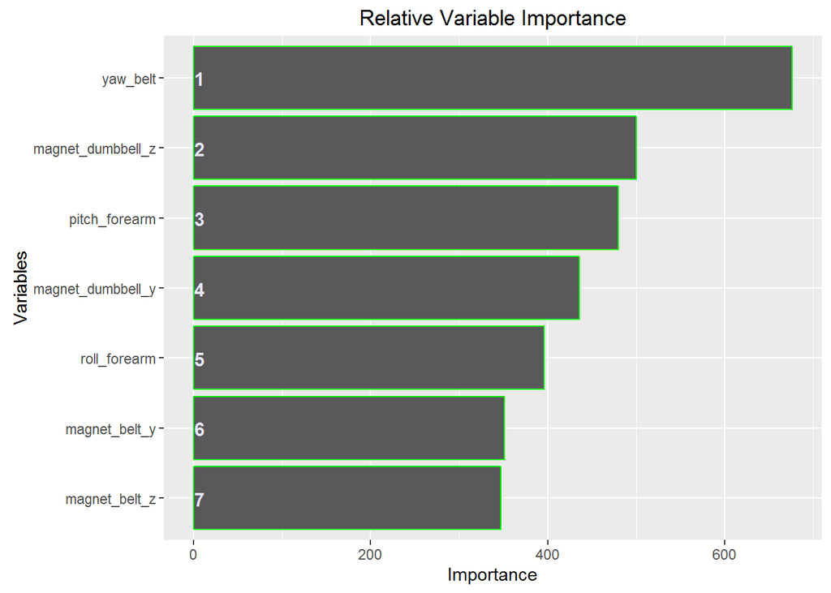

```r
# Use ggplot2 to visualize the relative importance of variables
ggplot(rankImportance[1:7,], aes(x = reorder(Variables, Importance),
    y = Importance)) +
  geom_bar(stat='identity', colour = 'green') +
  geom_text(aes(x = Variables, y = 0.5, label = Rank),
    hjust=0, vjust=0.55, size = 4, colour = 'lavender',
    fontface = 'bold') +
  labs(x = 'Variables', title = 'Relative Variable Importance') +
  coord_flip()
```

### Example of the tree rules for the 500’th tree in the random forest classifier

[output not shown]